**Project: Classification**

By Prof. Seungchul Lee  
http://iai.postech.ac.kr/  
Industrial AI Lab at POSTECH

# 0. Introduction

### Voice Classification

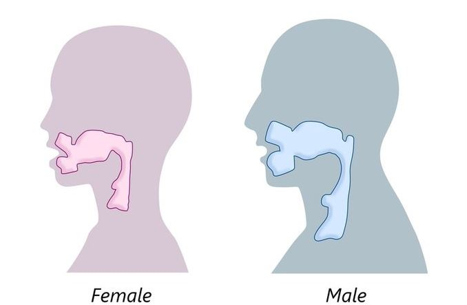

# 1. Data

## 1.1. Data_Load

```python
import numpy as np
import pandas as pd
import seaborn as sns
import matplotlib.pyplot as plt

from sklearn.model_selection import train_test_split
from sklearn import metrics
from sklearn.metrics import confusion_matrix
```

- Pandas를 사용하여 voice_ver2.csv 데이터 파일 load

```python
voice = pd.read_csv('./data_files/voice_ver2.csv')
voice
```

|  | meanfreq | sd | median | Q25 | Q75 | IQR | skew | kurt | sp.ent | sfm | ... | centroid | meanfun | minfun | maxfun | meandom | mindom | maxdom | dfrange | modindx | label |
| --- | --- | --- | --- | --- | --- | --- | --- | --- | --- | --- | --- | --- | --- | --- | --- | --- | --- | --- | --- | --- | --- |
| 0 | 0.059781 | 0.064241 | 0.032027 | 0.015071 | 0.090193 | 0.075122 | 12.863462 | 274.402906 | 0.893369 | 0.491918 | ... | 0.059781 | 0.084279 | 0.015702 | 0.275862 | 0.007812 | 0.007812 | 0.007812 | 0.000000 | 0.000000 | male |
| 1 | 0.066009 | 0.067310 | 0.040229 | 0.019414 | 0.092666 | 0.073252 | 22.423285 | 634.613855 | 0.892193 | 0.513724 | ... | 0.066009 | 0.107937 | 0.015826 | 0.250000 | 0.009014 | 0.007812 | 0.054688 | 0.046875 | 0.052632 | male |
| 2 | 0.077316 | 0.083829 | 0.036718 | 0.008701 | 0.131908 | 0.123207 | 30.757155 | 1024.927705 | 0.846389 | 0.478905 | ... | 0.077316 | 0.098706 | 0.015656 | 0.271186 | 0.007990 | 0.007812 | 0.015625 | 0.007812 | 0.046512 | male |
| 3 | 0.151228 | 0.072111 | 0.158011 | 0.096582 | 0.207955 | 0.111374 | 1.232831 | 4.177296 | 0.963322 | 0.727232 | ... | 0.151228 | 0.088965 | 0.017798 | 0.250000 | 0.201497 | 0.007812 | 0.562500 | 0.554688 | 0.247119 | male |
| 4 | 0.135120 | 0.079146 | 0.124656 | 0.078720 | 0.206045 | 0.127325 | 1.101174 | 4.333713 | 0.971955 | 0.783568 | ... | 0.135120 | 0.106398 | 0.016931 | 0.266667 | 0.712812 | 0.007812 | 5.484375 | 5.476562 | 0.208274 | male |
| ... | ... | ... | ... | ... | ... | ... | ... | ... | ... | ... | ... | ... | ... | ... | ... | ... | ... | ... | ... | ... | ... |
| 155 | 0.109148 | 0.091542 | 0.071577 | 0.024263 | 0.195321 | 0.171057 | 1.899222 | 6.472859 | 0.948618 | 0.678843 | ... | 0.109148 | 0.190846 | 0.030189 | 0.275862 | 0.359375 | 0.007812 | 0.718750 | 0.710938 | 0.354396 | female |
| 156 | 0.158417 | 0.081200 | 0.187643 | 0.085523 | 0.219079 | 0.133556 | 1.817030 | 7.238168 | 0.955927 | 0.698466 | ... | 0.158417 | 0.192754 | 0.062500 | 0.262295 | 0.359063 | 0.031250 | 0.921875 | 0.890625 | 0.315027 | female |
| 157 | 0.116002 | 0.088799 | 0.121542 | 0.023682 | 0.193980 | 0.170299 | 2.193672 | 8.404158 | 0.943584 | 0.676598 | ... | 0.116002 | 0.184000 | 0.086486 | 0.258065 | 0.338170 | 0.007812 | 0.710938 | 0.703125 | 0.403419 | female |
| 158 | 0.097733 | 0.080078 | 0.065308 | 0.032779 | 0.159893 | 0.127113 | 1.272920 | 3.865641 | 0.957693 | 0.715485 | ... | 0.097733 | 0.178400 | 0.021680 | 0.253968 | 0.525608 | 0.007812 | 4.257812 | 4.250000 | 0.178741 | female |
| 159 | 0.134045 | 0.091723 | 0.130709 | 0.041968 | 0.215606 | 0.173638 | 1.402166 | 5.278480 | 0.959689 | 0.725848 | ... | 0.134045 | 0.194586 | 0.027397 | 0.275862 | 0.396635 | 0.023438 | 1.070312 | 1.046875 | 0.302861 | female |

160 rows × 21 columns

## 1.2. Data_Checking null values

- 위에서 읽은 csv 파일에서 null값의 유무 확인하기 (Hint : Pandas의 `isnull` 사용)

```python
voice.isnull().sum()
```

```
meanfreq    0
sd          0
median      0
Q25         0
Q75         0
IQR         0
skew        0
kurt        0
sp.ent      0
sfm         0
mode        0
centroid    0
meanfun     0
minfun      0
maxfun      0
meandom     0
mindom      0
maxdom      0
dfrange     0
modindx     0
label       0
dtype: int64
```

## 1.3. Data_Labeling

- 앞에서 읽어온 voice의 x데이터와 y데이터를 분할
- y 값을 Male : 1, Female : 0로 변경 (Hint : Pandas의 `Categorical()`)
- x와 y 값을 numpy 형태로 변환

```python
voice_label = pd.Categorical(voice['label']).codes
voice_label = voice_label.reshape([-1,1])
voice_label
```

[output not shown]

[output cut: 105 more lines]

[output not shown]

```python
voice_feature = voice.iloc[:, :-1].values
```